# **How Data Augmentation Affects Deep Learning Performance**

# **Abstract:**

This tutorial will explore the impacts of data augmentation in relation to image classification. By training a Convolutional Neural Network (CNN) on the CIFAR-10 dataset and analysing how it compares to a baseline model and a model which uses an augmented dataset. Augmentation techniques such as flipping, jittering and rotating will be investigated, showing how they can be performed and what effects they have on an image. Readers should already have a basic understanding of CNNs. After completing the tutorial, they should gain a deeper understanding of data augmentation, its applications, and its impact on deep learning models.

# **Learning Objectives:**

- Understand how data augmentation impacts deep learning models
- Check the data for any missing or invalid data in a dataset
- Implement various augmentation techniques to images and see their effects
- Construct a new dataset by augmenting data
- Compare CNN training and validation on models using different datasets
- Understand how to analyse results using various visual methods

# **Table of Contents:**

- Tutorial Comparison
- Importing Libraries
- Data Downloading
- Data Preprocessing
- CNN Building
- Model Training
- Training and Validation Evaluation
- Testing Evaluation
- Conclusion
- References

## **Tutorial Comparison**

This section compares the following tutorial to other similar sources online. Below is a table of sources that were used as inspiration for the tutorial. It provides pros, cons and key differences.

## **Comparison Table**

| Tutorial | Pros | Cons | Key Difference |
| --- | --- | --- | --- |
| **[Using Data Augmentation for CNN](https://www.kaggle.com/code/eugeniyosetrov/using-data-augmentation-for-cnn)** | Provides clear examples of data augmentation, compares models trained on horizontal and vertical flipping | No comparison with non-augmented data, lacks a comparison on a test set of data | Uses a common test set for greater model evaluation |
| **[Training a CNN from Scratch using Data Augmentation](https://www.analyticsvidhya.com/blog/2022/09/training-a-cnn-from-scratch-using-data-augmentation/)** | Solid explanations of the augmentation types with examples | No hyperparameter tuning as only one model is used | Comparison of multiple models' performances |
| **[Guide to CNNs with Data Augmentation (Keras)](https://www.kaggle.com/code/moghazy/guide-to-cnns-with-data-augmentation-keras)** | Strong CNN exploration prior to model development | No performance comparison, lack of conclusion | Includes a detailed post-model results analysis with conclusions |
| **[The Essential Guide to Data Augmentation in Deep Learning](https://www.v7labs.com/blog/data-augmentation-guide)** | Covers augmentation techniques in great depth, includes key takeaways | No practical implementation | Provides a complete pipeline that expands on theory |
| **[The Essential Guide to Data Augmentation in Deep Learning (Medium)](https://medium.com/@saiwadotai/the-essential-guide-to-data-augmentation-in-deep-learning-f66e0907cdc8)** | Great theoretical analysis of augmentation techniques | Lacks practical implementation | Provides a complete pipeline that expands on theory |
| **[Image Augmentation for Deep Learning with Keras](https://machinelearningmastery.com/image-augmentation-deep-learning-keras/)** | Solid structure for data preprocessing | No performance comparison | Greater focus on results and evaluation |
| **[Training a Classifier](https://pytorch.org/tutorials/beginner/blitz/cifar10_tutorial.html)** | Solid pipeline structure and simplicity | No augmentation | A heavily increased focus on augmentation |

### **What makes this tutorial unique:**

Many online tutorials cover deep learning or data augmentation in detail, but few, if any, provide a direct comparison between an augmented dataset and a 'normal' dataset on a deep learning model like a CNN. This tutorial differs by doing exactly that. By displaying a complete machine learning pipeline, it showcases the effects of augmentation with an in-depth analysis of the different models. By using graphs and tables, the reader gains a clear understanding of data augmentation, providing unique insights which other tutorials fail to offer.

## **Importing Libraries**

Firstly, let's import all the required libraries for the tutorial ahead.

```python
# Importing the required libraries for the tutorial
import torch # PyTorch
import torchvision # PyTorch Vision Library
import torchvision.transforms as transforms # PyTorch Transformations
from torchvision.transforms import v2 # PyTorch Vision V2
import numpy as np # NumPy
import pandas as pd # Pandas
import torch.nn as nn # PyTorch Neural Network
import torch.nn.functional as F # PyTorch Functional
import torch.optim as optim # PyTorch Optimizer
from tabulate import tabulate # Tabulate
import seaborn as sns # Seaborn
from sklearn.metrics import confusion_matrix # Confusion Matrix
from sklearn.metrics import classification_report # Classification Report
import matplotlib.pyplot as plt # Matplotlib
```

## **Data Downloading**

We will now download the data by using PyTorch’s built-in features, as mentioned we will be using only the CIFAR-10 dataset. CIFAR-10 consists of 60,000 colour images which are each 32x32 pixels. 50,000 Images are used for training and the remaining 10,000 for testing. These images are split across 10 different classes: cars, birds, cats, frogs, horses, ships, deer, dogs, trucks and aeroplanes.

```python
# Downloading the CIFAR-10 dataset
# Data set and code from source [7]

'''
Transformation will be applied to each image as it is loaded in.
This is usefull for optimising the training proccess later on.
'''
transform = transforms.Compose([
    transforms.ToTensor(), # Converts PIL image into a tensor
    transforms.Normalize((0.5, 0.5, 0.5), (0.5, 0.5, 0.5)) # Normalises the tensor
])

# The training data is donwloaded (loaded if already downloaded)
trainset = torchvision.datasets.CIFAR10(
    root='./CIFAR10/',
    train=True,
    download=True,
    transform=transform
)

# The test data is donwloaded (loaded if already downloaded)
testset = torchvision.datasets.CIFAR10(
    root='./CIFAR10/',
    train=False,
    download=True,
    transform=transform
)

# Define the classes in the dataset
classes = ('plane', 'car', 'bird', 'cat',
           'deer', 'dog', 'frog', 'horse', 'ship', 'truck')

### end of source [7]
```

```
Files already downloaded and verified
Files already downloaded and verified
```

We then receive confirmation on whether the data has successfully been downloaded, or if it has already been downloaded.

## **Data preprocessing**

The next step is to understand the dataset in greater detail and check for any missing or invalid data.  
This is crucial especially when working with large datasets.  
The subsequent section involves checking the size and for any non-number (NaN) entries in both the testing and training data.

```python
# Function for checking NaN values in the dataset
def Data_Check(dataset):
    print("\nNumber of samples in dataset:", len(dataset))

    NaN_count = 0
    label_count = 0

    # Loop through the dataset
    for i in range(len(dataset)):
        image, label = dataset[i]

        # Check for NaN values
        if torch.isnan(image).any():
            NaN_count += 1

        # Check if the label is not an integer
        if not isinstance(label, int):
            label_count += 1

    # Print out the results
    print("\nNumber of samples containing NaN values in images:", NaN_count)
    print("Number of samples containing NaN values in labels:", label_count)


# Call the function to check NaN values
Data_Check(trainset)
Data_Check(testset)
```

```
Number of samples in dataset: 50000

Number of samples containing NaN values in images: 0
Number of samples containing NaN values in labels: 0

Number of samples in dataset: 10000

Number of samples containing NaN values in images: 0
Number of samples containing NaN values in labels: 0
```

The data set is already well prepared, there is no invalid data, so no additional cleaning is needed.

Now that we know for certain the data set is clean, it’s time to create the other datasets that will be used.

1. **Baseline:** The original CIFAR-10 dataset is randomly split in half, resulting in **25,000 images**. It will act as a reference point against the augmented dataset.
2. **Augmented:** This dataset is created by applying various augmentation techniques to the baseline dataset. This creates 25,000 augmented images, which are then merged back into the baseline dataset. This creates our second dataset which consists of **50,000 images**. This dataset will be used to evaluate how data augmentation Affects Deep Learning Performance.
3. **Original:** This is the original CIFAR-10 dataset, again containing **50,000 images**. This dataset will be compared to the baseline and augmented datasets, allowing us to understand how the augmented dataset compares to a 'normal' dataset of the same size.

```python
# Split the training data in half from source [8]
baseline, original_half = torch.utils.data.random_split(trainset, [25000, 25000])
### end of source [8]
```

Before creating the augmented dataset, let's visualise how each augmentation method affects an image. Each method described below will be individually applied to an image creating 6 more versions.

1. **Horizontal Flip:** Flips image along the Y-axis
2. **Vertical Flip:** Flips image along the X-axis
3. **Rotation:** Rotates the image to a degree of choice
4. **Affine Translation:** Moves the image in a random direction
5. **Colour Jitter:** Randomly changes the brightness, contrast, saturation and hue
6. **Random Crop:** Randomly crops a section of the photo with padding

```
Augmented images of a cat
```

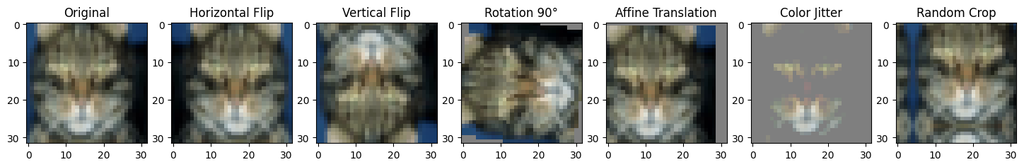

```python
# Define individual augmentations (each will be applied separately) from source [9]
augmentations = {
    "Original": None,
    "Horizontal Flip": v2.RandomHorizontalFlip(p=1.0), # Always flip horizontally
    "Vertical Flip": v2.RandomVerticalFlip(p=1.0), # Always flip vertically
    "Rotation 90°": v2.RandomRotation(90), # Rotate randomly to a degrees between -90° and +90°
    "Affine Translation": v2.RandomAffine(degrees=0, translate=(0.1, 0.1)), # Random translation
    "Color Jitter": v2.ColorJitter(brightness=0.1, contrast=0.1, saturation=0.1, hue=0.1), # Random color jitter
    "Random Crop": v2.RandomCrop(32, padding=4, padding_mode='reflect') # Random crop
}
### end of source [9]

# Select an image with its label
sample_image = 14
original_img, label = baseline[sample_image]

# Apply each augmentation to the selected image and store in a dictionary
augmented_images = {"Original": original_img}
for name, transform in augmentations.items():
    if transform:
        augmented_images[name] = transform(original_img)

# Function to display augmented images from source [7]
def imshow_grid(images):
    fig, axes = plt.subplots(1, len(images), figsize=(len(images) * 2, 2)) # Create the display grid
    for a, (name, img) in zip(axes, images.items()):
        img = img / 2 + 0.5  # Unnormalise
        npimg = img.numpy() # Convert to numpy array
        a.imshow(np.transpose(npimg, (1, 2, 0))) # Transpose
        a.set_title(name) # Show augmentation type
    plt.subplots_adjust(left=0, right=1, top=1, bottom=0)
    plt.show()
### end of source [7]

# Show augmented images in a single row
print("Augmented images of a", classes[label])
imshow_grid(augmented_images)
```

As we now understand how augmentation works, it's time to apply it on a greater scale to create the augmented dataset that will be used for testing.

```python
# The function takes an image from the baseline dataset and applies only one augmentation to it at random, from source [9]
aug_transforms = v2.Compose([
    v2.RandomChoice([
        v2.RandomHorizontalFlip(p=1.0), # Always flip horizontally
        v2.RandomVerticalFlip(p=1.0), # Always flip vertically
        v2.RandomRotation(90), # Rotate randomly to a degrees between -90° and +90°
        v2.RandomAffine(degrees=0, translate=(0.1, 0.1)), # Random translation
        v2.ColorJitter(brightness=0.1, contrast=0.1, saturation=0.1, hue=0.1), # Random color jitter
        v2.RandomCrop(32, padding=4, padding_mode='reflect') # Random crop
    ]),
])
### end of source [9]

# Create empty arrays to store the augmented images and labels
augmented_images = []
augmented_labels = []
# Apply augmentation to all images in the baseline dataset
for img, label in baseline:
    augmented_images.append(aug_transforms(img)) # Applies the augmentation to the image and stores it in the array
    augmented_labels.append(label) # Store the label unaltered

# Checks the number of training images and labels in the augmented dataset
print("Number of new augmented training images:", len(augmented_images))
print("Number of new augmented training labels:", len(augmented_labels))

# Merges the augmented images with the labels
augmented_dataset = list(zip(augmented_images, augmented_labels))

# Merges the augmented dataset with the baseline training set from source [8]
trainset_aug = torch.utils.data.ConcatDataset([baseline, augmented_dataset])
### end of source [8]

# Checks the number of images in the augmented dataset
print("Number of training images in the augmneted dataset:", len(trainset_aug))
```

```
Number of new augmented training images: 25000
Number of new augmented training labels: 25000
Number of training images in the augmneted dataset: 50000
```

After checking the size of the new dataset and confirming it is correct, we now have our three datasets for testing!

These datasets will account for the different hyper-parameters configurations and we will see how they affect the results.

# *Question: What are some advantages and disadvantages of data augmentation?*

**Click to see the answer!**

**Advantages:**

- Improved generalisation - Model learns robust patterns
- Reduced Overfitting - Model learns on more diverse data
- Increased Accuracy - More data leads to increased accuracy
- Cost Effective - Cheaper and faster than collecting new data

**Disadvantages:**

- Increased computational cost - Augmenting the data takes computational power
- May introduce noisy data - Data that is too augmented can lead to unrealistic distortions
- Only effective in certain datasets - i.e. Vertical flipping in a sign language data set could alter the meaning of the image

From source [11]

## **CNN Building**

Before we build and train the models, we need to specify a batch size and use a DataLoader that will handle the data in batches during training.

```python
# Specify how many images will be loaded at once
batch_size = 4

# This will be used later when training the model, it will be used to calculate the loss at intervals
evaluation = (1000 // batch_size) * batch_size
```

# *Question: What happens if the batch size is increased from 4?*

**Click to see the answer!**

Increasing the batch size can impact the model in the following ways:

**Pros:**

- Faster Training - Larger batches require fewer updates to weights and biases
- Lower Computational Costs - Larger batches require fewer updates to weights and biases

**Cons:**

- Weaker Generalisation - Models more frequently get stuck in local minima
- Slower Convergence - Less frequent updates can slow down learning

From source [12]

The next step is to split the data into training and vaildation sets.

We must create validation datasets for each of the three datasets we have created. Validation ensures that the model does not overtrain on the training data.

You will be able to see the results of training and validation as they get printed out during training, and later on, the loss values will be plotted onto a line grpah for a visual understanding and comparison.

Once the data has been split up into training and validation, they will be loaded into the dataloader ready for training.

```python
# Spliiting all 3 data sets into training and validation sets in a 80:20 ratio from source [8]
train_baseline, val_baseline = torch.utils.data.random_split(baseline, [20000, 5000])
train_aug, val_aug = torch.utils.data.random_split(trainset_aug, [40000, 10000])
train_orignial, val_original = torch.utils.data.random_split(trainset, [40000, 10000])
### end of source [8]

# Data loaders for training and validation, from source [7]
# Create a DataLoader for the baseline training data
trainloaderBase = torch.utils.data.DataLoader(train_baseline, batch_size=batch_size, shuffle=True, num_workers=2)

# Create a DataLoader for the baseline validation data
trainloaderBase_val = torch.utils.data.DataLoader(val_baseline, batch_size=batch_size, shuffle=True, num_workers=2)

# Create a DataLoader for the Augmented training data
trainloaderAug = torch.utils.data.DataLoader(train_aug, batch_size=batch_size, shuffle=True, num_workers=2)

# Create a DataLoader for the Augmented validaton data
trainloaderAug_val = torch.utils.data.DataLoader(val_aug, batch_size=batch_size, shuffle=True, num_workers=2)

# Create a DataLoader for the training data
trainloader = torch.utils.data.DataLoader(train_orignial, batch_size=batch_size, shuffle=True, num_workers=2)

# Create a DataLoader for the validation data
trainloader_val = torch.utils.data.DataLoader(val_original, batch_size=batch_size, shuffle=True, num_workers=2)

# Create a DataLoader for the test data
testloader = torch.utils.data.DataLoader(testset, batch_size=batch_size, shuffle=False, num_workers=2)

# End of source [7]
```

Below is the CNN model that we will be using to test our three datasets.

The model that is defined below is simple, the emphasis of this tutorial is to demonstrate and explore the effects of augmentation and not solely on optimisation of a deep learning model.

```python
# From source [7]
class Net(nn.Module):
    def __init__(self):
        super().__init__()
        self.conv1 = nn.Conv2d(3, 6, 5) # convolutional layer
        self.pool = nn.MaxPool2d(2, 2) # pooling layer
        self.conv2 = nn.Conv2d(6, 16, 5) # convolutional layer
        self.fc1 = nn.Linear(16 * 5 * 5, 120) # fully connected layer
        self.fc2 = nn.Linear(120, 84) # fully connected layer
        self.fc3 = nn.Linear(84, 10) # fully connected layer

    def forward(self, x):
        x = self.pool(F.relu(self.conv1(x))) # convolutional layer
        x = self.pool(F.relu(self.conv2(x))) # convolutional layer
        x = torch.flatten(x, 1) # flatten all dimensions except batch
        x = F.relu(self.fc1(x)) # fully connected layer
        x = F.relu(self.fc2(x)) # fully connected layer
        x = self.fc3(x) # fully connected layer
        return x
### end of source [7]
```

Below the loss function and the optimiser are defined, and then an instance of the model is initialised.

```python
# From source [7]
# Set rates for learning and momentum
learning_rate = 0.001
momentum = 0.9

net = Net() # Create an instance of the model
criterion = nn.CrossEntropyLoss() # Define loss function
optimizer = optim.SGD(net.parameters(), lr=learning_rate, momentum=momentum) # Define optimiser
### end of source [7]
```

A function is then defined to train and validate the model.

```python
# From source [7]
loss_values = [] # Stores training losses
val_loss_values = []  # Stores validation losses

def train_model(criterion, optimizer, train_loader, val_loader):
    individual_loss = [] # Stores training losses after each 1000 images
    individual_val_loss = [] # Stores validation losses after each 1000 images

    for epoch in range(2):  # Loop over the dataset multiple times
        running_loss = 0.0

        # Training
        net.train()
        for i, data in enumerate(train_loader, 0):
            # get the inputs; data is a list of [inputs, labels]
            inputs, labels = data

            # Zero the parameter gradients
            optimizer.zero_grad()

            # Forward + backward + optimize
            outputs = net(inputs)
            loss = criterion(outputs, labels)
            loss.backward()
            optimizer.step()

            # Statistics
            running_loss += loss.item()
            if i %  evaluation == (evaluation-1): # Print and store stats every 1000 images
                r_loss = running_loss / evaluation
                print(f'[{epoch + 1}, {i + 1:5d}] loss: {r_loss:.3f}')
                individual_loss.append(r_loss)
                running_loss = 0.0

                # Validation
                net.eval()
                val_running_loss = 0.0
                with torch.no_grad():
                    for data in val_loader:
                        inputs, labels = data
                        outputs = net(inputs)
                        loss = criterion(outputs, labels)
                        val_running_loss += loss.item()

                val_loss = val_running_loss / len(val_loader)
                print(f'Validation Loss: {val_loss:.3f}')
                individual_val_loss.append(val_loss)
                # Change back to training mode after validation
                net.train()

    print('Finished Training')

    # Append individual losses to the overall list
    loss_values.append(individual_loss)
    val_loss_values.append(individual_val_loss)

### end of source [7]
```

## **Model Training**

We will now train the model on the baseline dataset.

```python
# Train model with baseline data
train_model(criterion, optimizer, trainloaderBase, trainloaderBase_val)
# Save the model after training
torch.save(net.state_dict(), "Base_model.pth")
```

```
[1,  1000] loss: 2.280
Validation Loss: 2.185
[1,  2000] loss: 2.055
Validation Loss: 1.986
[1,  3000] loss: 1.898
Validation Loss: 1.814
[1,  4000] loss: 1.795
Validation Loss: 1.789
[1,  5000] loss: 1.709
Validation Loss: 1.739
[2,  1000] loss: 1.645
Validation Loss: 1.593
[2,  2000] loss: 1.590
Validation Loss: 1.638
[2,  3000] loss: 1.583
Validation Loss: 1.523
[2,  4000] loss: 1.522
Validation Loss: 1.544
[2,  5000] loss: 1.526
Validation Loss: 1.503
Finished Training
```

A function is then created to workout the total accuracy of the dataset.

```python
# From source [7]
# Stores the accuracys of the models
accuracy_totals = []

def accuracy(net, testloader):
    correct = 0
    total = 0
    # since we're not training, we don't need to calculate the gradients for our outputs
    with torch.no_grad():
        for data in testloader:
            images, labels = data
            # calculate outputs by running images through the network
            outputs = net(images)
            # the class with the highest energy is what we choose as prediction
            _, predicted = torch.max(outputs, 1)
            total += labels.size(0)
            correct += (predicted == labels).sum().item()

    tot_acc = 100 * correct // total
    print(f'Accuracy of the network on the 10000 test images: {tot_acc} %')
    print('Total Accuracy Complete!')
    accuracy_totals.append(tot_acc)

### end of source [7]
```

We then call the function to work out the accuracy of the baseline dataset.

```python
# Calculate the accuracy of the baseline model
accuracy(net, testloader)
```

```
Accuracy of the network on the 10000 test images: 45 %
Total Accuracy Complete!
```

For a more in-depth understanding of the accuracy, a function is defined to work out the accuracies of each class.

```python
# From source [7]

# Stores the accuracys of the models individual classes
classes_accuracy = []
# Stores predicted and actual labels
all_labels = []
all_preds = []

def class_accuracy(net, testloader):
    all_labels_save = []
    all_preds_save = []
    # prepare to count predictions for each class
    correct_pred = {classname: 0 for classname in classes}
    total_pred = {classname: 0 for classname in classes}

    # again no gradients needed
    with torch.no_grad():
        for data in testloader:
            images, labels = data
            outputs = net(images)
            _, predictions = torch.max(outputs, 1)

            # Append actual and predicted labels
            all_labels_save.append(labels)
            all_preds_save.append(predictions)

            # collect the correct predictions for each class
            for label, prediction in zip(labels, predictions):
                if label == prediction:
                    correct_pred[classes[label]] += 1
                total_pred[classes[label]] += 1

    all_labels.append(all_labels_save)
    all_preds.append(all_preds_save)
    class_individual = []
    # print accuracy for each class
    for classname, correct_count in correct_pred.items():
        accuracy = 100 * float(correct_count) / total_pred[classname]
        class_individual.append(accuracy)
        print(f'Accuracy for class: {classname:5s} is {accuracy:.1f} %')
    classes_accuracy.append(class_individual)
    print('Class Accuracy Complete!')

### end of source [7]
```

We then call the function to workout the indivdual class accuracy for each class.

```python
# Calculate the individual class accuracya of the baseline model
class_accuracy(net, testloader)
```

```
Accuracy for class: plane is 55.4 %
Accuracy for class: car   is 52.9 %
Accuracy for class: bird  is 47.4 %
Accuracy for class: cat   is 18.5 %
Accuracy for class: deer  is 35.2 %
Accuracy for class: dog   is 35.7 %
Accuracy for class: frog  is 47.8 %
Accuracy for class: horse is 68.7 %
Accuracy for class: ship  is 49.4 %
Accuracy for class: truck is 47.3 %
Class Accuracy Complete!
```

The next step is to train and evaluate the other two data sets on the same CNN model.

```python
# Defining datasets and save paths for the models
datasets = {
    "Augmented": (trainloaderAug, trainloaderAug_val, "Aug_model.pth"),
    "Original": (trainloader, trainloader_val, "Orig_model.pth")
}

# Loop through each dataset and train the model
for name, (train_loader, val_loader, save_path) in datasets.items():
    print(f"\nTraining and Evaluating {name} Model:")

    # From source [7]
    # Reset the model
    net = Net()
    criterion = nn.CrossEntropyLoss()
    optimizer = optim.SGD(net.parameters(), lr=learning_rate, momentum=momentum)

    # Train the model
    train_model(criterion, optimizer, train_loader, val_loader)

    # Save trained model
    torch.save(net.state_dict(), save_path)

    # Evaluate the model
    accuracy(net, testloader)
    class_accuracy(net, testloader)
    ### end of source [7]
```

```
Training and Evaluating Augmented Model:
```

```
[1,  1000] loss: 2.299
Validation Loss: 2.284
[1,  2000] loss: 2.168
Validation Loss: 2.075
[1,  3000] loss: 2.028
Validation Loss: 1.971
[1,  4000] loss: 1.941
Validation Loss: 1.890
[1,  5000] loss: 1.844
Validation Loss: 1.863
[1,  6000] loss: 1.800
Validation Loss: 1.729
[1,  7000] loss: 1.753
Validation Loss: 1.763
[1,  8000] loss: 1.721
Validation Loss: 1.690
[1,  9000] loss: 1.695
Validation Loss: 1.642
[1, 10000] loss: 1.685
Validation Loss: 1.629
[2,  1000] loss: 1.626
Validation Loss: 1.594
[2,  2000] loss: 1.586
Validation Loss: 1.610
[2,  3000] loss: 1.604
Validation Loss: 1.586
[2,  4000] loss: 1.583
Validation Loss: 1.574
[2,  5000] loss: 1.560
Validation Loss: 1.603
[2,  6000] loss: 1.575
Validation Loss: 1.522
[2,  7000] loss: 1.554
Validation Loss: 1.552
[2,  8000] loss: 1.557
Validation Loss: 1.565
[2,  9000] loss: 1.527
Validation Loss: 1.535
[2, 10000] loss: 1.499
Validation Loss: 1.486
```

[output cut: 55 more lines]

```
Validation Loss: 1.284
Finished Training
Accuracy of the network on the 10000 test images: 54 %
Total Accuracy Complete!
Accuracy for class: plane is 56.5 %
Accuracy for class: car   is 55.8 %
Accuracy for class: bird  is 28.6 %
Accuracy for class: cat   is 29.0 %
Accuracy for class: deer  is 55.0 %
Accuracy for class: dog   is 56.6 %
Accuracy for class: frog  is 65.9 %
Accuracy for class: horse is 62.1 %
Accuracy for class: ship  is 60.2 %
Accuracy for class: truck is 70.3 %
Class Accuracy Complete!
```

## **Training and Validation Evaluation**

Now that all 3 models have been trained we can evaluate the data!

Firstly, let's create a graph to explore the training and validation data.

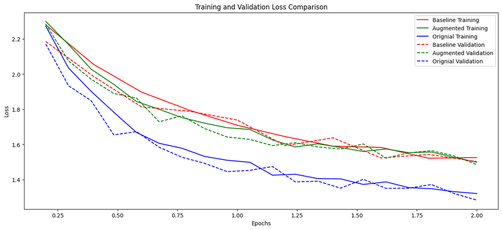

```python
# Plot the training and validation loss for each model on the same graph
def plot_loss(Base_train_losses, Aug_train_losses, Orig_train_losses, Base_val_losses, Aug_val_losses, Orig_val_losses):
    plt.figure(figsize=(12, 5))

    # Create the plot from source [19]
    plt.plot((np.linspace(0.2, 2, len(Base_train_losses))), Base_train_losses, color = 'r', label='Baseline Training')
    plt.plot((np.linspace(0.2, 2, len(Aug_train_losses))), Aug_train_losses, color = 'g', label='Augmented Training')
    plt.plot((np.linspace(0.2, 2, len(Orig_train_losses))), Orig_train_losses, color = 'b', label='Orignial Training')
    plt.plot((np.linspace(0.2, 2, len(Base_train_losses))), Base_val_losses, color = 'r', linestyle='dashed', label='Baseline Validation')
    plt.plot((np.linspace(0.2, 2, len(Aug_val_losses))), Aug_val_losses, color = 'g', linestyle='dashed', label='Augmented Validation')
    plt.plot((np.linspace(0.2, 2, len(Orig_val_losses))), Orig_val_losses, color = 'b', linestyle='dashed', label='Orignial Validation')
    plt.xlabel("Epochs")
    plt.ylabel("Loss")
    plt.title("Training and Validation Loss Comparison")
    plt.legend()
    plt.subplots_adjust(left=0, right=1, top=1, bottom=0)
    plt.show()
### end of source [19]

Base_train_losses = loss_values[0]
Aug_train_losses = loss_values[1]
Orig_train_losses = loss_values[2]
Base_val_losses = val_loss_values[0]
Aug_val_losses = val_loss_values[1]
Orig_val_losses = val_loss_values[2]

plot_loss(Base_train_losses, Aug_train_losses, Orig_train_losses, Base_val_losses, Aug_val_losses, Orig_val_losses)
```

The original data set performed the best during training and validation. It learned the fastest, shown by the steepest gradient, and had the lowest loss values out of all three datasets. The augmented and baseline datasets had little difference between them as they both displayed a similar trajectory. They both had shallower gradients, indicating slower learning and ended up with higher loss values when compared to the original dataset.  
However, while the augmented set did not perform exceptionally, its true performance will be evaluated on the test set, where we can see how well it generalises to unseen data.  
For all of them, it is important to notice that overtraining did not occur using the original parameters, you can tell as the dashed line for each respective dataset is still on a decreasing gradient.

## **Testing Evaluation**

This section compares all the models created on the test set of data.

Firstly, we will create a table to explore how each dataset performed against each other. Their overall and individual class accuracy will be compared.

```python
# Displaying results in a table from source [10]
# Table headers
headers = ["", "Baseline (%)", "Augmented (%)", "Original (%)"]

# List to store the table data
tabledata = []

# Add overall accuracy
tabledata.append(["Overall Accuracy"] + accuracy_totals)

# Add individual class accuracys
for idx, class_name in enumerate(classes):
    row = [f"Accuracy for {class_name}"] + [classes_accuracy[i][idx] for i in range(len(classes_accuracy))]
    tabledata.append(row)

# Display table
print(tabulate(tabledata, headers=headers, tablefmt="fancy_grid"))

### end of source [10]
```

```
╒════════════════════╤════════════════╤═════════════════╤════════════════╕
│                    │   Baseline (%) │   Augmented (%) │   Original (%) │
╞════════════════════╪════════════════╪═════════════════╪════════════════╡
│ Overall Accuracy   │           45   │            50   │           54   │
├────────────────────┼────────────────┼─────────────────┼────────────────┤
│ Accuracy for plane │           55.4 │            38.5 │           56.5 │
├────────────────────┼────────────────┼─────────────────┼────────────────┤
│ Accuracy for car   │           52.9 │            60.4 │           55.8 │
├────────────────────┼────────────────┼─────────────────┼────────────────┤
│ Accuracy for bird  │           47.4 │            25.1 │           28.6 │
├────────────────────┼────────────────┼─────────────────┼────────────────┤
│ Accuracy for cat   │           18.5 │            38.4 │           29   │
├────────────────────┼────────────────┼─────────────────┼────────────────┤
│ Accuracy for deer  │           35.2 │            49.8 │           55   │
├────────────────────┼────────────────┼─────────────────┼────────────────┤
│ Accuracy for dog   │           35.7 │            38.5 │           56.6 │
├────────────────────┼────────────────┼─────────────────┼────────────────┤
│ Accuracy for frog  │           47.8 │            62.1 │           65.9 │
├────────────────────┼────────────────┼─────────────────┼────────────────┤
│ Accuracy for horse │           68.7 │            56.5 │           62.1 │
├────────────────────┼────────────────┼─────────────────┼────────────────┤
│ Accuracy for ship  │           49.4 │            81.2 │           60.2 │
├────────────────────┼────────────────┼─────────────────┼────────────────┤
│ Accuracy for truck │           47.3 │            58.3 │           70.3 │
╘════════════════════╧════════════════╧═════════════════╧════════════════╛
```

What we can take away from this table:

- **Overall Accuracy:** The original dataset the performed best **(54%)**, closely followed by augmented **(50%)**, and baseline performed the worst **(45%)**.
- **Where augmentation increased in performance:** It had big improvements in accuracy compared to the baseline for ships **(+31.8%)** and cats **(+19.9%)**.
- **Where augmentation decreased in performance:** It significantly dropped in accuracy compared to baseline for birds **(-22.3%)** and planes **(-16.9%)**.

Augmentation improved generalisation for some classes but introduced noise for others, this resulted in an inconsistent performance. While it outperformed the baseline in terms of overall accuracy, further adjustments may be needed to bridge the gap to the original dataset.

Augmentation had a higher accuracy than original for **ships, cats and cars**, displaying its potential to out perform the a dataset of the same size which is made up of non augmented images.

For a more visual approach we will now plot the individual classes accuracy on a bar chart. This allows for an easier comparison across different classes to see how augmentation has impacted specific categories.

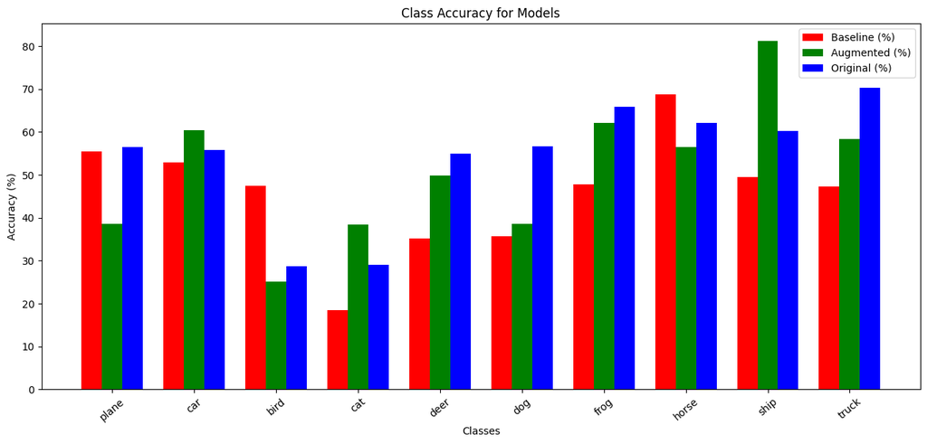

```python
# Accuracy data for Baseline, Augmented, and Original models
baseline = classes_accuracy[0]
augmented = classes_accuracy[1]
original = classes_accuracy[2]

# From source [13]
# Set bar width
bar_width = 0.25

# Set position of bars on X-axis
h = np.arange(len(classes))
h1 = h
h2 = [pos + bar_width for pos in h1]
h3 = [pos + bar_width for pos in h2]


# Plot bars
plt.figure(figsize=(12, 5))
plt.bar(h1, baseline, width=bar_width, color = 'r', label="Baseline (%)")
plt.bar(h2, augmented, width=bar_width, color = 'g', label="Augmented (%)")
plt.bar(h3, original, width=bar_width, color = 'b', label="Original (%)")

# Labels and title
plt.xlabel("Classes")
plt.ylabel("Accuracy (%)")
plt.title("Class Accuracy for Models")
plt.xticks([pos + bar_width for pos in h], classes, rotation=40)
plt.subplots_adjust(left=0, right=1, top=1, bottom=0)
plt.legend()
### end of source [13]
```

We will now explore metrics such as **precision, recall, and f1 - score.** This provides additional details on performance, looking further than accuracy, helping us understand how well each model has handled true or false positives and negatives.

```python
i = 0

# Loop all the labels
for i in range(len(all_labels)):
    # flatten both sets of labels from source [20]
    real = torch.cat(all_labels[i]).numpy()
    pred = torch.cat(all_preds[i]).numpy()
    ### end of source [20]

    if i == 0:
        title = "baseline"
    elif i == 1:
        title = "Augmented"
    else:
        title = "Original"

    # Store classification report as a dictionary
    dict_classification = classification_report(real, pred, output_dict=True)

    # Convert dictionary to dataframe
    df_report = pd.DataFrame(dict_classification).transpose()

    # Map class int to class name
    df_report.rename(index={str(i): classes[i] for i in range(len(classes))}, inplace=True)

    # Convert dataframe to a table
    table_str = tabulate(df_report, headers="keys", tablefmt="grid")

    print(f"\nClassification Report for Model: {title}")
    print(table_str)
```

```
Classification Report for Model: baseline
+--------------+-------------+----------+------------+------------+
|              |   precision |   recall |   f1-score |    support |
+==============+=============+==========+============+============+
| plane        |    0.450773 |   0.554  |   0.497084 |  1000      |
+--------------+-------------+----------+------------+------------+
| car          |    0.655514 |   0.529  |   0.585501 |  1000      |
+--------------+-------------+----------+------------+------------+
| bird         |    0.321792 |   0.474  |   0.38334  |  1000      |
+--------------+-------------+----------+------------+------------+
| cat          |    0.345149 |   0.185  |   0.240885 |  1000      |
+--------------+-------------+----------+------------+------------+
| deer         |    0.359918 |   0.352  |   0.355915 |  1000      |
+--------------+-------------+----------+------------+------------+
| dog          |    0.458869 |   0.357  |   0.401575 |  1000      |
+--------------+-------------+----------+------------+------------+
| frog         |    0.578692 |   0.478  |   0.523549 |  1000      |
+--------------+-------------+----------+------------+------------+
| horse        |    0.414105 |   0.687  |   0.516736 |  1000      |
+--------------+-------------+----------+------------+------------+
| ship         |    0.571759 |   0.494  |   0.530043 |  1000      |
+--------------+-------------+----------+------------+------------+
| truck        |    0.556471 |   0.473  |   0.511351 |  1000      |
+--------------+-------------+----------+------------+------------+
| accuracy     |    0.4583   |   0.4583 |   0.4583   |     0.4583 |
+--------------+-------------+----------+------------+------------+
| macro avg    |    0.471304 |   0.4583 |   0.454598 | 10000      |
+--------------+-------------+----------+------------+------------+
| weighted avg |    0.471304 |   0.4583 |   0.454598 | 10000      |
+--------------+-------------+----------+------------+------------+

Classification Report for Model: Augmented
+--------------+-------------+----------+------------+------------+
|              |   precision |   recall |   f1-score |    support |
+==============+=============+==========+============+============+
| plane        |    0.625    |   0.385  |   0.476485 |  1000      |
+--------------+-------------+----------+------------+------------+
| car          |    0.627859 |   0.604  |   0.615698 |  1000      |
+--------------+-------------+----------+------------+------------+
| bird         |    0.438811 |   0.251  |   0.319338 |  1000      |
```

[output cut: 37 more lines]

```
+--------------+-------------+----------+------------+-----------+
| frog         |    0.552389 |    0.659 |   0.601003 |   1000    |
+--------------+-------------+----------+------------+-----------+
| horse        |    0.595398 |    0.621 |   0.60793  |   1000    |
+--------------+-------------+----------+------------+-----------+
| ship         |    0.699187 |    0.602 |   0.646964 |   1000    |
+--------------+-------------+----------+------------+-----------+
| truck        |    0.515018 |    0.703 |   0.594503 |   1000    |
+--------------+-------------+----------+------------+-----------+
| accuracy     |    0.54     |    0.54  |   0.54     |      0.54 |
+--------------+-------------+----------+------------+-----------+
| macro avg    |    0.549641 |    0.54  |   0.535385 |  10000    |
+--------------+-------------+----------+------------+-----------+
| weighted avg |    0.549641 |    0.54  |   0.535385 |  10000    |
+--------------+-------------+----------+------------+-----------+
```

# *What do these metrics mean?*

**If you are unsure click to see an explanation!**

**Precision:** Out of all the positive predictions, how many are actually positive?

**Recall (Sensitivity):** Out of all actual positives, how many are predicted correctly?

**F1-score:** The harmonic mean of precision and recall, a single metric that balances both metrics above.

**Support:** Count of samples in the given classes

From source [16]

### **Concise Model Comparisons**

Below is a table that combines the overall key metrics for each model.

| Model | Precision | Recall | F1-Score |
| --- | --- | --- | --- |
| **Baseline** | 0.471 | 0.458 | 0.455 |
| **Augmented** | 0.519 | 0.509 | 0.501 |
| **Original** | 0.550 | 0.540 | 0.535 |

### **Analysis:**

As we can see they all follow similar trends to accuracy, with original performing the best, baseline the worst and augmented in the middle of them.

- Augmented increases precision compared to baseline **(0.471 to 0.519)**, however, it is still lower than the original data set.
- Recall had the most significant improvement from baseline **(0.458 to 0.509)**, however, the gap from augmented to original was similar to the other metrics.
- Augmented increases F1-Score compared to baseline **(0.455 to 0.501)**, but again it is still lower than the original data set.

This further provides evidence that augmentation helps bridge the gap from the baseline dataset, but it still doesn’t outperform the original model.

The final evaluation technique we will explore is heatmaps, which represent correlation matrices. Each class will be plotted against each other for each dataset, allowing us to visualise how well the model correctly classified or wrongly misclassified one class as another.

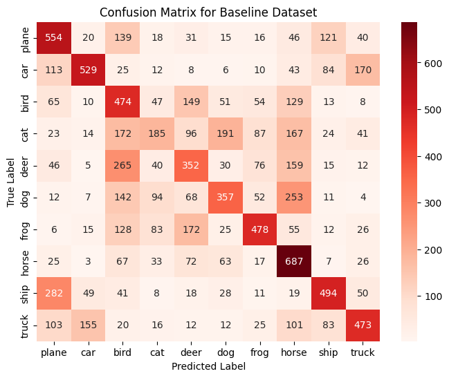

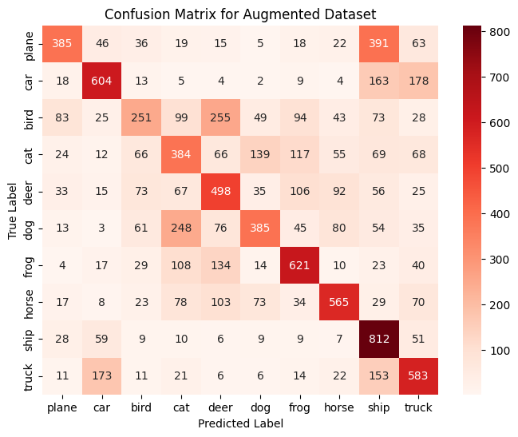

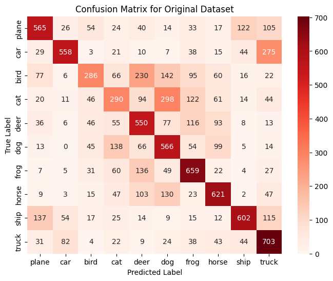

```python
# Loop through each index in all_labels and all_preds
for i in range(len(all_labels)):
    # flatten both sets of labels from source [20]
    real = torch.cat(all_labels[i]).numpy()
    pred = torch.cat(all_preds[i]).numpy()
    ### end of source [20]

    # Create confusion matrix from source [14]
    c_matrix = confusion_matrix(real, pred)
    ### end of source [14]

    if i == 0:
        title = "Baseline"
    elif i == 1:
        title = "Augmented"
    else:
        title = "Original"

    # Plot confusion matrix
    plt.figure(figsize=(8, 6))
    # Create heatmap from source [15]
    sns.heatmap(c_matrix, annot=True, fmt="d", cmap="Reds", xticklabels=classes, yticklabels=classes)
    ### end of source [15]
    plt.xlabel("Predicted Label")
    plt.ylabel("True Label")
    plt.title(f"Confusion Matrix for {title} Dataset")
    plt.show()
```

**Baseline:**

- Solid performances in some classes such as **plane and horse**.
- High misclassification in similar classes, such as **cat to dog (191)**.
- There are also considerable misclassifications in **ship to plane (282)** and **deer to bird (265)**.
- The **cat** class has a large spread of misclassification.

In general, the performance is not awful. However, there are still some considerable improvements that could be made, especially for certain classes.

**Augmented:**

- A Higher amount of correctly classified classes, big improvements include **ship (+318) and frog (+143)**, this displays an improvement in learning for these classes.
- Increased misclassification for **car, cat, and ship**. This can suggest that augmentation introduced noise into the dataset, resulting in the model struggling for those classes.
- There is still a misclassification between **cat to dog (139)**, however, it has slightly improved from the baseline.

Augmentation looks to have improved generalisation for most classes but decreased performance in others. Again, this suggests that while augmentation can be beneficial, there is still a need for further refinement.

**Original:**

- Best general performance across all classes, with **truck (703)** being the highest predicted class.
- Still signs of misclassification in similar classes, such as **cat to dog** or even **car to truck**.
- Less extreme misclassification compared to the augmented dataset, showing its increased performance over the other it.

The original dataset provided the best overall balanced performance; however, even this dataset is still far from perfect.

## **Conclusion**

This tutorial showcases a machine learning pipeline using PyTorch within Jupiter notebooks. From downloading the data to creating captivating visuals, it displays the essential steps required in a pipeline, while also emphasising the role of data augmentation can have.

Throughout this tutorial, we have discovered that when limited data is available, data augmentation can be used as a feasible option. Although new and different data is the most effective option, augmentation boasts impressive results as a quick, simple, and effective way to expand the size of the dataset. In our example, it increased the overall accuracy from **baseline: 45%** to **augmented: 50%**, showcasing its potential. This is further supported by the bar chart, accuracy metrics and confusion matrices which visualise a more in-depth comparison between all three datasets.

However, in specific classes, augmentation did not improve the baseline model and potentially introduced noise into the dataset. As has been mentioned throughout, the model itself and the augmented data can be further fine-tuned to increase accuracy.

Future work would expand on this. A deeper analysis of each data augmentation technique could help identify the most optimal transformations, rather than randomly assigning them. In addition, experiments involving more extreme augmentation methods could be conducted to see whether they positively impact the model or introduce more noise in the dataset.

## **References**

**Research:**

[1] E. Osetrov. "Using Data Augmentation for CNN." *Kaggle*. Accessed: Mar. 1, 2025. [Online]. Available: https://www.kaggle.com/code/eugeniyosetrov/using-data-augmentation-for-cnn

[2] Nazia. "Training a CNN from Scratch Using Data Augmentation." *Analytics Vidhya*. Accessed: Mar. 1, 2025. [Online]. Available: https://www.analyticsvidhya.com/blog/2022/09/training-a-cnn-from-scratch-using-data-augmentation/

[3] Moghazy. "Guide to CNNs with Data Augmentation – Keras." *Kaggle*. Accessed: Mar. 2, 2025. [Online]. Available: https://www.kaggle.com/code/moghazy/guide-to-cnns-with-data-augmentation-keras

[4] D. Shah, "Data Augmentation Guide." *V7 Labs*. Accessed: Mar. 2, 2025. [Online]. Available: https://www.v7labs.com/blog/data-augmentation-guide

[5] Saiwa. "The Essential Guide to Data Augmentation in Deep Learning." *Medium*. Accessed: Mar. 1, 2025. [Online]. Available: https://medium.com/@saiwadotai/the-essential-guide-to-data-augmentation-in-deep-learning-f66e0907cdc8

[6] J. Brownlee. "Image Augmentation for Deep Learning with Keras." *Machine Learning Mastery*. Accessed: Mar. 3, 2025. [Online]. Available: https://machinelearningmastery.com/image-augmentation-deep-learning-keras/

**Code:**

[8] PyTorch. "torch.utils.data" *PyTorch Documentation*. Accessed: Mar. 4, 2025. [Online]. Available: https://pytorch.org/docs/stable/data.html

[9] PyTorch. "Transforming and augmenting images." *PyTorch Documentation*. Accessed: Mar. 4, 2025. [Online]. Available: https://pytorch.org/vision/main/transforms.html

[10] PyPI. "tabulate." *PyPI*. Accessed: Mar. 4, 2025. [Online]. Available: https://pypi.org/project/tabulate/

[13] GeeksforGeeks. "Bar Plot in Matplotlib." *GeeksforGeeks*. Accessed: Mar. 5, 2025. [Online]. Available: https://www.geeksforgeeks.org/bar-plot-in-matplotlib/

[14] Scikit-learn. "confusion_matrix." *Scikit-learn Documentation*. Accessed: Mar. 5, 2025. [Online]. Available: https://scikit-learn.org/stable/modules/generated/sklearn.metrics.confusion_matrix.html

[15] Seaborn. "seaborn.heatmap." *Seaborn Documentation*. Accessed: Mar. 5, 2025. [Online]. Available: https://seaborn.pydata.org/generated/seaborn.heatmap.html

[19] Matplotlib. "matplotlib.pyplot.plot." *Matplotlib Documentation*. Accessed: Mar. 6, 2025. [Online]. Available: https://matplotlib.org/stable/api/_as_gen/matplotlib.pyplot.plot.html

[20] PyTorch. "torch.cat." *PyTorch Documentation*. Accessed: Mar. 6, 2025. [Online]. Available: https://pytorch.org/docs/main/generated/torch.cat.html

**Research and Code:**

[7] PyTorch. "Training a Classifier." *PyTorch Tutorials*. Accessed: Mar. 1, 2025. [Online]. Available: https://pytorch.org/tutorials/beginner/blitz/cifar10_tutorial.html

**Markdowns:**

[17] DataCamp. "Markdown in Jupyter Notebook Tutorial." *DataCamp Tutorial*. Accessed: Mar. 1, 2025. [Online]. Available: https://www.datacamp.com/tutorial/markdown-in-jupyter-notebook

[18] IBM. "Markdown for Jupyter notebooks cheatsheet." *IBM Documentation*. Accessed: Mar. 2, 2025. [Online]. Available: https://www.ibm.com/docs/en/watson-studio-local/1.2.3?topic=notebooks-markdown-jupyter-cheatsheet

**Dropdowns:**

[11] P. Hallaj. "Data Augmentation: Benefits and Disadvantages." *Medium*. Accessed: Mar. 9, 2025. [Online]. Available: https://medium.com/@pouyahallaj/data-augmentation-benefits-and-disadvantages-38d8201aead

[12] Devansh "How Does Batch Size Impact Your Model Learning?" *Medium*. Accessed: Mar. 10, 2025. [Online]. Available: https://medium.com/geekculture/how-does-batch-size-impact-your-model-learning-2dd34d9fb1fa

[16] P. Kashyap. "Understanding Precision, Recall, and F1-Score Metrics." *Medium*. Accessed: Mar. 10, 2025. [Online]. Available: https://medium.com/@piyushkashyap045/understanding-precision-recall-and-f1-score-metrics-ea219b908093